# Music Popularity Over The Years

Non Pronanun, Jacob Waltzer, Carson Klein, Cole Graham

2/18/2022

**INFO-201: Technical Foundations of Informatics - The Information School - University of Washington**

**Date:** Winter 2022

**Abstract**

Our main question is how do societal changes influence the popularity of music genres which is important because music is a very large industry and is influential in many people’s lives. To address this question we will evaluate the most popular songs since the 1950s and their attributes (i.e. beats per minute, year, genre, etc.), Spotify premium subscribers per quarter since 2015, and number of music sales depending on medium. Our main concern is that there is not enough extensive and reliable data; To address this concern we will find as much data as possible and compare to ensure accuracy. Considering that music is more accessible than ever, this is important because music is integral to lives of people. Accordingly, we plan to observe trends in data pertaining to popularity of music genres.

### Keywords

- Music genre
- Popularity
- Societal changes
- Barriers to entry

### 1.0 Introduction

An area of interest that we shared and chose to analyze is music. Today, music is something that is universal, almost everyone listens to music in their leisure time. People’s source of music has also evolved over the years and when we think of music nowadays, we don’t think of cassette tapes and turntables anymore, rather we lean towards music digitalization and streaming platforms such as Spotify or Apple Music. In recent years, these platforms grew rapidly with almost 400 million monthly listeners from Spotify alone. Therefore, we wanted to find out the growth patterns of these platforms and analyze their development over the years.

### 2.0 Design Situation

**1.** The first situation that we found is the number of subscribers of Spotify premium since Q1 of 2015. [Number of Spotify premium subscribers worldwide from 1st quarter 2015 to 3rd quarter 2021](https://www.statista.com/statistics/244995/number-of-paying-spotify-subscribers/)

[figure not shown]

* the human values present is the growth of this industry which may provide people with more opportunities, such as jobs, and also to be able to estimate the reason and the trends for this growth. The direct stakeholders are the listeners of Spotify, since these are the main users of Spotify and this data is a representation of them, and Spotify themselves, as they are responsible for the maintenance/growth of the platform. The indirect stakeholders are other music digitalization platforms.

**2.** The second situation that we found was the number of sales regarding the music industry. In this dataset, there were 3,008 observations for 5 columns (format(CD, tape, etc.), metric. the years, and the number of records sold.) of the number of sales between 1973 to 2019.

- the human values from this set is the transgression of music from physical copies of songs such as CDs, Vinyl records, and tapes towards streaming platforms and music digitalization downloads. From this, we can draw connections to the genres that were dominant in each era of the different mediums of listening to music, or the favorable mediums of music in each decade. The direct stakeholders are listeners of music and those who are responsible for the production of these different sources of music. The indirect stakeholders here are people who make music, as they might not know about the progression of how people listen to music.

**3.** The third design situation that we considered is the songs that were most popular in each decade from 1950 to 2019. This dataset is made by Spotify and it shows specific details of each song that we can gain more insight into the direction of which song is popular in the given timeframe.

- For this dataset, the human values of this dataset deals most with which songs that the general populous determines as more popular throughout the recent few decades. The direct stakeholders here are the people that listen to music since the 1950, since these data provides a representation of the direction that music popularity is going. The indirect stakeholders for this can be the people who are distributing music, as they might not know the trends of popularity of music, but are responsible for giving people access to music.

### 3.0 Research Questions

- How do societal changes influence the popularity of specific music genres?
- How do changing barriers to entry influence the popularity of specific music genres?

These questions are important because they aim to lead to a better understanding of the changing involvement of music in our lives. Music represents a major part of society, and we shape music trends as much as they shape our world. With the lower barriers to entry, this is more true now than it ever has been, as more people are involved in creating and listening to music than in the past.

### 4.0 The Dataset

#### Size

The data set is actually made up of 7 different files. Each file represents a decade (starting from the 1950s going up to 2010s) and each file has about 100 top songs from the decade and includes about 15 attributes about each row (song). Each song has plenty of information and the dataset is well organized in that it includes the most useful information about the most popular songs of every decade.

#### Complexity

The dataset is decently complex and includes basic attributes like song name, artists, year, but also more complex features like bpm of each song, energy level, dB, duration, and even how much of the song is spoken word. It will be useful to know the year and artists, even the labeled genre of every song, but looking at more quantitative data like song length and dB level of the most popular songs will show more concrete trends throughout the decades.

#### Origins

The data and information itself is collected from Spotify. Spotify has playlists that highlight the top songs from each decade, so even though Spotify does not have direct numbers about how popular songs were on its platform going back to the 1950’s (obviously), they have playlists from each decade and of course are able to collect data from every recording that is posted on its platform. The data files have been compiled on Kaggle, where we got it, but the original data is from Spotify. The data is raw and is not written to push an agenda or sell a particular artist, it is available to help answer and explore questions regarding every decade. We plan on using this data set to explore possible trends in the real world (like introduction of steaming platforms, rising popularity of social media, cultural shifts, etc.) and how it may affect trends in music popularity.

### 5.0 Expected Implications

Given that we know the answer to our design question, we think that this will give the people a clearer picture in the growth of these platforms and from this, they may be able to have an idea on what may have caused such rapid growths. This data might also help those who are looking to enter the music industry, since it will allow them to know the best way to gain recognition or know if music digitalization platforms can serve as a basis for their careers. As for the platforms themselves, they might be able to find patterns in the causation in rapid growths or whether they have exhausted the demand for music digitalization a certain region/genre or not.

### 6.0 Limitations

Mainly the limitations for this project is that certain data are not made publicly available, these may include the specific geographical demographics of listeners. In addition, due to these platforms being relatively new and still adjusting and evolving with the general populous, it is hard to be sure about the accuracy of some of the statistics. Old data may also not be reliable as they don’t have a sample size and accuracy than the data that we have today.

## Summary Paragraph

Our dataset consists of information about the most popular songs since the 1940s. Data included categories such as artist, song title, genre, year, beats per minute, a scale for decibels, and more. We decided to group our data by decade and then analyze the features of the songs from each decade. We did this because we were more interested in the trends of songs over time rather than the specific attributes of a particular song or artist. Our compiled dataset included 667 songs, and we found that the decade with the longests songs (by average) were the 1980’s which had an average song length of 254.3 seconds (4 minutes 14 second). The decade with the loudest songs on average (measured in decibels) were the 2000s. The 1940’s had the fastest songs in terms of beats per minute with an average of 127 bpm. The final attribute that we analyzed was called “nrgy”, which measures the “energy” of a song, and although it was not measured with common units, the higher the nrgy value, the more energetic the song was reported to be. The decade that had the most energetic songs was the 2000s.

## Aggregate Table

```r
summary_table
```

```
## # A tibble: 8 x 6
##   decade mean_bpm mean_energy mean_dance mean_decibels mean_duration
##    <dbl>    <dbl>       <dbl>      <dbl>         <dbl>         <dbl>
## 1   1940    127          20         46          -13.5           146
## 2   1950     91.7        36.3       44          -10.4           163.
## 3   1960    119.         50.3       51.2        -11.4           214.
## 4   1970    121.         60.9       55.6         -9.26          236.
## 5   1980    122.         60.5       60.6         -9.86          254.
## 6   1990    120.         62.7       61.5         -8.75          237.
## 7   2000    120.         65.8       65.5         -6.86          227.
## 8   2010    117.         63.6       62.2         -6.87          201.
```

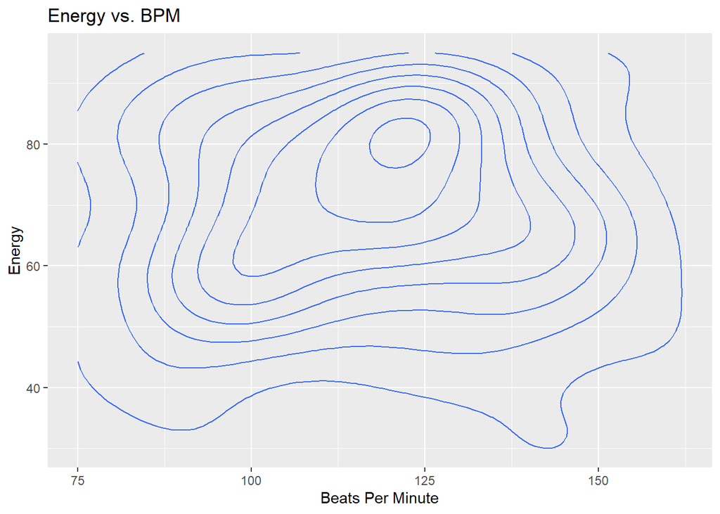

Purpose: to see the correlation between the BPM and the energy level of a song. It’s a common belief that faster songs (higher BPM) have higher energy.

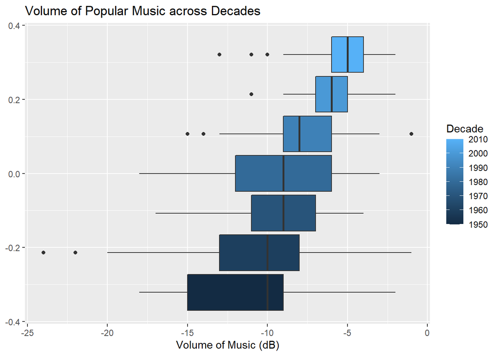

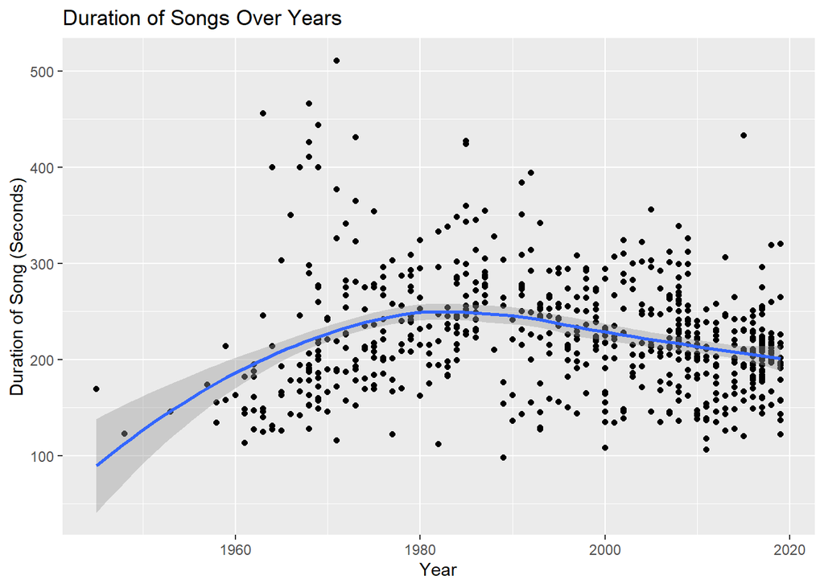

This scatterplot shows how the duration of songs (in seconds) has changed since the late 1940s through the 2010s. In addition to the actual points, I drew the averages of each year in a blue line to show the trend. The trend shows that when data first started being collected, the songs were closer to the 100-150 second, and maxed out at around the 250 second range in the 1980s. Recently, the songs have become shorter and shorter, now averaging around the 200 second mark.